# find_tsne_settings_moran

This notebook is intended to explore the 1.1.3.15 data and figure out the storyline.  
Copyright (C) 2017 Martin Engqvist Lab  
This program is free software: you can redistribute it and/or modify  
it under the terms of the GNU General Public License as published by  
the Free Software Foundation, either version 3 of the License, or  
(at your option) any later version.  
This program is distributed in the hope that it will be useful,  
but WITHOUT ANY WARRANTY; without even the implied warranty of  
MERCHANTABILITY or FITNESS FOR A PARTICULAR PURPOSE. See the  
GNU General Public License for more details.  
You should have received a copy of the GNU General Public License  
along with this program. If not, see http://www.gnu.org/licenses/.

```python
import os
from dotenv import load_dotenv, find_dotenv
from os.path import join, dirname, basename, exists, isdir

### Load environmental variables from the project root directory ###
# find .env automagically by walking up directories until it's found
dotenv_path = find_dotenv()

# load up the entries as environment variables
load_dotenv(dotenv_path)

# now you can get the variables using their names

# Check whether a network drive has been specified
DATABASE = os.environ.get("NETWORK_URL")
if DATABASE == 'None':
    pass
else:
    pass
    #mount network drive here

# set up directory paths
CURRENT_DIR = os.getcwd()
PROJ = dirname(dotenv_path) # project root directory

DATA = join(PROJ, 'data') #data directory
RAW_EXTERNAL = join(DATA, 'raw_external') # external data raw directory
RAW_INTERNAL = join(DATA, 'raw_internal') # internal data raw directory
INTERMEDIATE = join(DATA, 'intermediate') # intermediate data directory
FINAL = join(DATA, 'final') # final data directory

RESULTS = join(PROJ, 'results') # output directory
FIGURES = join(RESULTS, 'figures') # figure output directory
PICTURES = join(RESULTS, 'pictures') # picture output directory


# make folders specific for certain data
folder_name = 'similarity_data'
if folder_name != '':
#     #make folders if they don't exist
#     if not exists(join(RAW_EXTERNAL, folder_name)):
#         os.makedirs(join(RAW_EXTERNAL, folder_name))

#     if not exists(join(INTERMEDIATE, folder_name)):
#         os.makedirs(join(INTERMEDIATE, folder_name))

    if not exists(join(FINAL, folder_name)):
        os.makedirs(join(FINAL, folder_name))

print('Standard variables loaded, you are good to go!')
```

```
Standard variables loaded, you are good to go!
```

```python
import json
import re
import random
import pandas as pd
import numpy as np

import matplotlib.pyplot as plt
from matplotlib.patches import Rectangle
import seaborn as sns; sns.set(style="ticks", color_codes=True)

import sklearn
from sklearn.decomposition import PCA
from sklearn.manifold import MDS

from colcol import scales

# import tsne
import sys; sys.path.append('/home/localadmin/github/FIt-SNE')
from fast_tsne import fast_tsne
```

#### Load the 1.1.3.15 sequences encoded using Moran autocorrelation

```python
# got a bunch of data from the iFeatures server, let's plot them

## load autocorrelation data and drop duplicates ##
filepath = join(FINAL, 'BRENDA', 'Moran.tsv')
moran = pd.read_csv(filepath, sep='\t').drop_duplicates()

# replace the first column with identifiers
moran['#'] = [i.split(';')[0] for i in moran['#']]
moran.rename(columns={'#':'uid'}, inplace=True)
#display(moran.head())


## load uid to ec mapping and merge ##
filepath = join(FINAL, 'BRENDA', 'ec_uid_org_from_fasta.tsv')
uid_ec = pd.read_csv(filepath, sep='\t').drop_duplicates()
#display(uid_ec.head())

moran = moran.merge(uid_ec, on=['uid'])


## load organism and temperature information and merge ##
filepath = join(FINAL, 'BRENDA', '1-1-3-n_identifier_info.tsv')
uid_property = pd.read_csv(filepath, sep='\t').drop_duplicates()

uid_property.drop(['lineage_identifiers', 'lineage_ranks', 'lineage_names'],
                  inplace=True,
                 axis=1)
#display(uid_property.head())

moran = moran.merge(uid_property, on=['uid'])


# # only keep 1.1.3.15
moran_subset = moran[moran['ec']=='1.1.3.15']
# moran_subset = moran

display(moran_subset.head())
display(moran_subset.describe())
```

|  | uid | CIDH920105.lag1 | CIDH920105.lag2 | CIDH920105.lag3 | CIDH920105.lag4 | CIDH920105.lag5 | CIDH920105.lag6 | CIDH920105.lag7 | CIDH920105.lag8 | CIDH920105.lag9 | ... | DAYM780201.lag28 | DAYM780201.lag29 | DAYM780201.lag30 | ec | taxid | organism | superkingdom | ph | temperature | pfam |
| --- | --- | --- | --- | --- | --- | --- | --- | --- | --- | --- | --- | --- | --- | --- | --- | --- | --- | --- | --- | --- | --- |
| 33 | Q9LRS0 | -0.112260 | -0.026338 | 0.024954 | -0.042846 | -0.005068 | 0.001836 | -0.037387 | -0.023635 | 0.028922 | ... | 0.054946 | -0.006965 | 0.063072 | 1.1.3.15 | 3702.0 | Arabidopsis thaliana | Eukaryota | NaN | NaN | NaN |
| 34 | Q9NYQ3 | -0.060426 | -0.060405 | 0.017934 | -0.058830 | 0.010837 | 0.059738 | -0.059371 | 0.018331 | -0.019532 | ... | 0.043622 | 0.038505 | 0.063350 | 1.1.3.15 | 9606.0 | Homo sapiens | Eukaryota | NaN | NaN | NaN |
| 35 | P37339 | 0.015468 | -0.119128 | -0.072430 | -0.059787 | -0.007129 | -0.002287 | 0.027105 | 0.065397 | -0.021576 | ... | 0.046805 | 0.005792 | 0.039488 | 1.1.3.15 | 83333.0 | Escherichia coli | Bacteria | 7.01 | 36.0 | NaN |
| 36 | Q24JJ8 | -0.087069 | -0.046749 | 0.024775 | 0.015878 | 0.006658 | -0.024912 | 0.003307 | -0.059712 | -0.011642 | ... | 0.072317 | -0.015191 | 0.119261 | 1.1.3.15 | 3702.0 | Arabidopsis thaliana | Eukaryota | NaN | NaN | NaN |
| 37 | B8AUI3 | -0.080660 | -0.050749 | 0.006042 | -0.032405 | -0.006934 | 0.041389 | -0.005770 | -0.045086 | -0.046021 | ... | 0.001053 | 0.029839 | 0.057644 | 1.1.3.15 | 39946.0 | Oryza sativa | Eukaryota | NaN | NaN | NaN |

5 rows × 248 columns

|  | CIDH920105.lag1 | CIDH920105.lag2 | CIDH920105.lag3 | CIDH920105.lag4 | CIDH920105.lag5 | CIDH920105.lag6 | CIDH920105.lag7 | CIDH920105.lag8 | CIDH920105.lag9 | CIDH920105.lag10 | ... | DAYM780201.lag24 | DAYM780201.lag25 | DAYM780201.lag26 | DAYM780201.lag27 | DAYM780201.lag28 | DAYM780201.lag29 | DAYM780201.lag30 | taxid | ph | temperature |
| --- | --- | --- | --- | --- | --- | --- | --- | --- | --- | --- | --- | --- | --- | --- | --- | --- | --- | --- | --- | --- | --- |
| count | 1411.000000 | 1411.000000 | 1411.000000 | 1411.000000 | 1411.000000 | 1411.000000 | 1411.000000 | 1411.000000 | 1411.000000 | 1411.000000 | ... | 1411.000000 | 1411.000000 | 1411.000000 | 1411.000000 | 1411.000000 | 1411.000000 | 1411.000000 | 1.258000e+03 | 811.000000 | 1036.000000 |
| mean | -0.027602 | -0.083103 | -0.041211 | -0.048102 | -0.043046 | -0.012369 | 0.004777 | 0.013097 | -0.017733 | 0.010542 | ... | 0.011023 | 0.010330 | -0.028455 | 0.004822 | 0.023328 | 0.012915 | 0.016062 | 6.496091e+05 | 7.024032 | 33.610039 |
| std | 0.043157 | 0.038950 | 0.045260 | 0.036990 | 0.053737 | 0.039256 | 0.041164 | 0.048915 | 0.050344 | 0.033766 | ... | 0.043115 | 0.046516 | 0.050028 | 0.046602 | 0.046779 | 0.041235 | 0.043931 | 5.306286e+05 | 0.445190 | 7.201882 |
| min | -0.175810 | -0.187126 | -0.177962 | -0.198238 | -0.205680 | -0.145063 | -0.163658 | -0.144557 | -0.173901 | -0.163431 | ... | -0.144623 | -0.154738 | -0.156661 | -0.208620 | -0.172209 | -0.143863 | -0.146183 | 1.950000e+02 | 1.500000 | 10.000000 |
| 25% | -0.060724 | -0.114644 | -0.072840 | -0.066745 | -0.085390 | -0.038082 | -0.017139 | -0.022769 | -0.044273 | -0.005945 | ... | -0.017825 | -0.008884 | -0.062913 | -0.019104 | -0.007500 | -0.014144 | -0.009473 | 1.020845e+05 | 7.000000 | 29.000000 |
| 50% | -0.017672 | -0.093336 | -0.055314 | -0.057648 | -0.019816 | -0.002870 | 0.019983 | 0.023875 | -0.022251 | 0.016672 | ... | 0.022824 | 0.019398 | -0.038549 | 0.013508 | 0.040698 | 0.013950 | 0.024115 | 5.666790e+05 | 7.010000 | 36.000000 |
| 75% | 0.011442 | -0.054522 | -0.010711 | -0.027455 | -0.002897 | 0.012325 | 0.032047 | 0.057193 | 0.000289 | 0.025140 | ... | 0.040419 | 0.035920 | 0.007825 | 0.025764 | 0.055046 | 0.033878 | 0.040582 | 1.126095e+06 | 7.120000 | 36.000000 |
| max | 0.127566 | 0.059874 | 0.103743 | 0.178075 | 0.071945 | 0.110373 | 0.154425 | 0.133428 | 0.190519 | 0.185342 | ... | 0.136545 | 0.225062 | 0.168202 | 0.144936 | 0.197409 | 0.188968 | 0.188883 | 1.835254e+06 | 9.000000 | 90.000000 |

8 rows × 243 columns

```python
moran[moran['ec']=='1.1.3.15'].groupby('superkingdom').count()
```

| superkingdom | uid | CIDH920105.lag1 | CIDH920105.lag2 | CIDH920105.lag3 | CIDH920105.lag4 | CIDH920105.lag5 | CIDH920105.lag6 | CIDH920105.lag7 | CIDH920105.lag8 | CIDH920105.lag9 | ... | DAYM780201.lag27 | DAYM780201.lag28 | DAYM780201.lag29 | DAYM780201.lag30 | ec | taxid | organism | ph | temperature | pfam |
| --- | --- | --- | --- | --- | --- | --- | --- | --- | --- | --- | --- | --- | --- | --- | --- | --- | --- | --- | --- | --- | --- |
| Archaea | 27 | 27 | 27 | 27 | 27 | 27 | 27 | 27 | 27 | 27 | ... | 27 | 27 | 27 | 27 | 27 | 27 | 27 | 12 | 12 | 2 |
| Bacteria | 1160 | 1160 | 1160 | 1160 | 1160 | 1160 | 1160 | 1160 | 1160 | 1160 | ... | 1160 | 1160 | 1160 | 1160 | 1160 | 1160 | 1160 | 793 | 1012 | 463 |
| Eukaryota | 66 | 66 | 66 | 66 | 66 | 66 | 66 | 66 | 66 | 66 | ... | 66 | 66 | 66 | 66 | 66 | 66 | 66 | 6 | 12 | 1 |
| hydrocarbon metagenome | 1 | 1 | 1 | 1 | 1 | 1 | 1 | 1 | 1 | 1 | ... | 1 | 1 | 1 | 1 | 1 | 1 | 1 | 0 | 0 | 1 |
| hydrothermal vent metagenome | 2 | 2 | 2 | 2 | 2 | 2 | 2 | 2 | 2 | 2 | ... | 2 | 2 | 2 | 2 | 2 | 2 | 2 | 0 | 0 | 0 |

5 rows × 247 columns

#### I also want to get data regarding which cluster the sequences are in

```python
uid_dict = {k:None for k in moran_subset.uid.values}

filepath = join(FINAL, 'BRENDA')

for fi in os.listdir(filepath):
    if fi.endswith('sequences.fasta'):
        cluster = fi.replace('_sequences.fasta', '')

        with open(join(filepath, fi), 'r') as f:
            for line in f:
                if line.startswith('>'):
                    uid = line.strip('>').split(';')[0]
                    uid_dict[uid] = cluster

data = {'uid':[], 'cluster':[]}
for k,v in uid_dict.items():
    data['uid'].append(k)
    data['cluster'].append(v)


moran_subset = moran_subset.merge(pd.DataFrame(data), on='uid')

display(moran_subset.head())
display(moran_subset.tail())
```

|  | uid | CIDH920105.lag1 | CIDH920105.lag2 | CIDH920105.lag3 | CIDH920105.lag4 | CIDH920105.lag5 | CIDH920105.lag6 | CIDH920105.lag7 | CIDH920105.lag8 | CIDH920105.lag9 | ... | DAYM780201.lag29 | DAYM780201.lag30 | ec | taxid | organism | superkingdom | ph | temperature | pfam | cluster |
| --- | --- | --- | --- | --- | --- | --- | --- | --- | --- | --- | --- | --- | --- | --- | --- | --- | --- | --- | --- | --- | --- |
| 0 | Q9LRS0 | -0.112260 | -0.026338 | 0.024954 | -0.042846 | -0.005068 | 0.001836 | -0.037387 | -0.023635 | 0.028922 | ... | -0.006965 | 0.063072 | 1.1.3.15 | 3702.0 | Arabidopsis thaliana | Eukaryota | NaN | NaN | NaN | cluster_2 |
| 1 | Q9NYQ3 | -0.060426 | -0.060405 | 0.017934 | -0.058830 | 0.010837 | 0.059738 | -0.059371 | 0.018331 | -0.019532 | ... | 0.038505 | 0.063350 | 1.1.3.15 | 9606.0 | Homo sapiens | Eukaryota | NaN | NaN | NaN | cluster_2 |
| 2 | P37339 | 0.015468 | -0.119128 | -0.072430 | -0.059787 | -0.007129 | -0.002287 | 0.027105 | 0.065397 | -0.021576 | ... | 0.005792 | 0.039488 | 1.1.3.15 | 83333.0 | Escherichia coli | Bacteria | 7.01 | 36.0 | NaN | cluster_0 |
| 3 | Q24JJ8 | -0.087069 | -0.046749 | 0.024775 | 0.015878 | 0.006658 | -0.024912 | 0.003307 | -0.059712 | -0.011642 | ... | -0.015191 | 0.119261 | 1.1.3.15 | 3702.0 | Arabidopsis thaliana | Eukaryota | NaN | NaN | NaN | cluster_2 |
| 4 | B8AUI3 | -0.080660 | -0.050749 | 0.006042 | -0.032405 | -0.006934 | 0.041389 | -0.005770 | -0.045086 | -0.046021 | ... | 0.029839 | 0.057644 | 1.1.3.15 | 39946.0 | Oryza sativa | Eukaryota | NaN | NaN | NaN | cluster_2 |

5 rows × 249 columns

|  | uid | CIDH920105.lag1 | CIDH920105.lag2 | CIDH920105.lag3 | CIDH920105.lag4 | CIDH920105.lag5 | CIDH920105.lag6 | CIDH920105.lag7 | CIDH920105.lag8 | CIDH920105.lag9 | ... | DAYM780201.lag29 | DAYM780201.lag30 | ec | taxid | organism | superkingdom | ph | temperature | pfam | cluster |
| --- | --- | --- | --- | --- | --- | --- | --- | --- | --- | --- | --- | --- | --- | --- | --- | --- | --- | --- | --- | --- | --- |
| 1406 | D5MNA0 | -0.019897 | -0.045952 | -0.033997 | -0.104952 | -0.073588 | -0.029521 | 0.002725 | -0.039698 | -0.021743 | ... | 0.059771 | -0.057053 | 1.1.3.15 | 671143.0 | Candidatus methylomirabilis | Bacteria | NaN | NaN | NaN | cluster_1 |
| 1407 | A9QH69 | -0.025620 | -0.080459 | -0.012838 | -0.018964 | -0.069405 | 0.023047 | -0.065116 | -0.055592 | -0.040492 | ... | 0.048410 | 0.139829 | 1.1.3.15 | 1346.0 | Streptococcus iniae | Bacteria | 7.10 | 37.0 | NaN | cluster_2 |
| 1408 | A9QH71 | -0.017994 | -0.077614 | -0.013174 | -0.029345 | -0.075070 | 0.026757 | -0.063626 | -0.043916 | -0.029382 | ... | 0.045098 | 0.136383 | 1.1.3.15 | 1346.0 | Streptococcus iniae | Bacteria | 7.10 | 37.0 | NaN | cluster_2 |
| 1409 | Q9CG58 | -0.055570 | -0.068812 | 0.044555 | -0.040743 | -0.084378 | 0.012376 | -0.073711 | -0.005313 | 0.049385 | ... | -0.066732 | -0.017744 | 1.1.3.15 | 272623.0 | Lactococcus lactis | Bacteria | 7.04 | 31.0 | NaN | cluster_2 |
| 1410 | Q5SM78 | -0.006481 | -0.030430 | -0.059004 | -0.053925 | -0.111905 | -0.024116 | -0.091825 | -0.050494 | 0.005238 | ... | 0.033699 | -0.007914 | 1.1.3.15 | 300852.0 | Thermus thermophilus | Bacteria | 7.18 | 71.0 | NaN | cluster_1 |

5 rows × 249 columns

#### I need to load the activity data

```python
filepath = join(FINAL, 'experiments')

batch1 = pd.read_csv(join(filepath, '1-1-3-n_batch1_summary.tsv'), sep='\t')
batch2 = pd.read_csv(join(filepath, '1-1-3-n_batch2_summary.tsv'), sep='\t')

# rename the column for the identifier
batch1.rename(columns={'node':'uid'}, inplace=True)
batch2.rename(columns={'name':'uid'}, inplace=True)

# add info on which batch it is
batch1['batch'] = 'first'
batch2['batch'] = 'second'

# check that there are no duplicates
for uid in batch1.uid.values:
    if uid in batch2.uid.values:
        print('Bad overlap, uid %s exists in both datasets' % uid)


# combine them
both_batches = batch1.append(batch2).drop_duplicates()

# drop unnessecary columns
both_batches = both_batches[(both_batches['synthesized'] == 'Yes') |
                            (both_batches['synthesized'] == 'No')]
both_batches.drop(['rep1_soluble',
                   'rep1_active',
                   'rep2_soluble',
                   'rep2_active',
                   'rep3_soluble',
                   'rep3_active'], axis=1, inplace=True)

display(both_batches.head())


# make sure all the identfiers are there in the main dataset
# for uid in both_batches.uid.values:
#     assert uid in moran_subset.uid.values
# print('all uids present in main dataset')


# now merge with the other data
moran_subset = moran_subset.merge(both_batches, on='uid', how='left')

# replace nans
moran_subset = moran_subset.replace(np.nan, '', regex=True)

display(moran_subset.head())
display(moran_subset.tail())
```

|  | uid | synthesized | substrate_available | total_soluble | total_active | batch |
| --- | --- | --- | --- | --- | --- | --- |

|  | uid | CIDH920105.lag1 | CIDH920105.lag2 | CIDH920105.lag3 | CIDH920105.lag4 | CIDH920105.lag5 | CIDH920105.lag6 | CIDH920105.lag7 | CIDH920105.lag8 | CIDH920105.lag9 | ... | superkingdom | ph | temperature | pfam | cluster | synthesized | substrate_available | total_soluble | total_active | batch |
| --- | --- | --- | --- | --- | --- | --- | --- | --- | --- | --- | --- | --- | --- | --- | --- | --- | --- | --- | --- | --- | --- |
| 0 | Q9LRS0 | -0.112260 | -0.026338 | 0.024954 | -0.042846 | -0.005068 | 0.001836 | -0.037387 | -0.023635 | 0.028922 | ... | Eukaryota |  |  |  | cluster_2 |  |  |  |  |  |
| 1 | Q9NYQ3 | -0.060426 | -0.060405 | 0.017934 | -0.058830 | 0.010837 | 0.059738 | -0.059371 | 0.018331 | -0.019532 | ... | Eukaryota |  |  |  | cluster_2 |  |  |  |  |  |
| 2 | P37339 | 0.015468 | -0.119128 | -0.072430 | -0.059787 | -0.007129 | -0.002287 | 0.027105 | 0.065397 | -0.021576 | ... | Bacteria | 7.01 | 36 |  | cluster_0 |  |  |  |  |  |
| 3 | Q24JJ8 | -0.087069 | -0.046749 | 0.024775 | 0.015878 | 0.006658 | -0.024912 | 0.003307 | -0.059712 | -0.011642 | ... | Eukaryota |  |  |  | cluster_2 |  |  |  |  |  |
| 4 | B8AUI3 | -0.080660 | -0.050749 | 0.006042 | -0.032405 | -0.006934 | 0.041389 | -0.005770 | -0.045086 | -0.046021 | ... | Eukaryota |  |  |  | cluster_2 |  |  |  |  |  |

5 rows × 254 columns

|  | uid | CIDH920105.lag1 | CIDH920105.lag2 | CIDH920105.lag3 | CIDH920105.lag4 | CIDH920105.lag5 | CIDH920105.lag6 | CIDH920105.lag7 | CIDH920105.lag8 | CIDH920105.lag9 | ... | superkingdom | ph | temperature | pfam | cluster | synthesized | substrate_available | total_soluble | total_active | batch |
| --- | --- | --- | --- | --- | --- | --- | --- | --- | --- | --- | --- | --- | --- | --- | --- | --- | --- | --- | --- | --- | --- |
| 1406 | D5MNA0 | -0.019897 | -0.045952 | -0.033997 | -0.104952 | -0.073588 | -0.029521 | 0.002725 | -0.039698 | -0.021743 | ... | Bacteria |  |  |  | cluster_1 |  |  |  |  |  |
| 1407 | A9QH69 | -0.025620 | -0.080459 | -0.012838 | -0.018964 | -0.069405 | 0.023047 | -0.065116 | -0.055592 | -0.040492 | ... | Bacteria | 7.1 | 37 |  | cluster_2 |  |  |  |  |  |
| 1408 | A9QH71 | -0.017994 | -0.077614 | -0.013174 | -0.029345 | -0.075070 | 0.026757 | -0.063626 | -0.043916 | -0.029382 | ... | Bacteria | 7.1 | 37 |  | cluster_2 |  |  |  |  |  |
| 1409 | Q9CG58 | -0.055570 | -0.068812 | 0.044555 | -0.040743 | -0.084378 | 0.012376 | -0.073711 | -0.005313 | 0.049385 | ... | Bacteria | 7.04 | 31 |  | cluster_2 |  |  |  |  |  |
| 1410 | Q5SM78 | -0.006481 | -0.030430 | -0.059004 | -0.053925 | -0.111905 | -0.024116 | -0.091825 | -0.050494 | 0.005238 | ... | Bacteria | 7.18 | 71 |  | cluster_1 |  |  |  |  |  |

5 rows × 254 columns

#### Add information regarding which sequences are marked as characterized in BRENDA

```python
active_in_brenda = ['A0A011QK89', 'A0A077SBA9', 'A0A0U6K8E5', 'R0EVG9', 'S2DJ52'] # BRENDA version x, table y

active = []
for uid in active_in_brenda:
    active.append('Yes')

brenda_df = pd.DataFrame({'uid':active_in_brenda, 'in_brenda':active})


# merge with data frame
moran_subset = moran_subset.merge(brenda_df, on=['uid'], how='left')

# replace nans
moran_subset = moran_subset.replace(np.nan, 'No', regex=True)

display(moran_subset.head())
display(moran_subset.tail())
```

|  | uid | CIDH920105.lag1 | CIDH920105.lag2 | CIDH920105.lag3 | CIDH920105.lag4 | CIDH920105.lag5 | CIDH920105.lag6 | CIDH920105.lag7 | CIDH920105.lag8 | CIDH920105.lag9 | ... | ph | temperature | pfam | cluster | synthesized | substrate_available | total_soluble | total_active | batch | in_brenda |
| --- | --- | --- | --- | --- | --- | --- | --- | --- | --- | --- | --- | --- | --- | --- | --- | --- | --- | --- | --- | --- | --- |
| 0 | Q9LRS0 | -0.112260 | -0.026338 | 0.024954 | -0.042846 | -0.005068 | 0.001836 | -0.037387 | -0.023635 | 0.028922 | ... |  |  |  | cluster_2 |  |  |  |  |  | No |
| 1 | Q9NYQ3 | -0.060426 | -0.060405 | 0.017934 | -0.058830 | 0.010837 | 0.059738 | -0.059371 | 0.018331 | -0.019532 | ... |  |  |  | cluster_2 |  |  |  |  |  | No |
| 2 | P37339 | 0.015468 | -0.119128 | -0.072430 | -0.059787 | -0.007129 | -0.002287 | 0.027105 | 0.065397 | -0.021576 | ... | 7.01 | 36 |  | cluster_0 |  |  |  |  |  | No |
| 3 | Q24JJ8 | -0.087069 | -0.046749 | 0.024775 | 0.015878 | 0.006658 | -0.024912 | 0.003307 | -0.059712 | -0.011642 | ... |  |  |  | cluster_2 |  |  |  |  |  | No |
| 4 | B8AUI3 | -0.080660 | -0.050749 | 0.006042 | -0.032405 | -0.006934 | 0.041389 | -0.005770 | -0.045086 | -0.046021 | ... |  |  |  | cluster_2 |  |  |  |  |  | No |

5 rows × 255 columns

|  | uid | CIDH920105.lag1 | CIDH920105.lag2 | CIDH920105.lag3 | CIDH920105.lag4 | CIDH920105.lag5 | CIDH920105.lag6 | CIDH920105.lag7 | CIDH920105.lag8 | CIDH920105.lag9 | ... | ph | temperature | pfam | cluster | synthesized | substrate_available | total_soluble | total_active | batch | in_brenda |
| --- | --- | --- | --- | --- | --- | --- | --- | --- | --- | --- | --- | --- | --- | --- | --- | --- | --- | --- | --- | --- | --- |
| 1406 | D5MNA0 | -0.019897 | -0.045952 | -0.033997 | -0.104952 | -0.073588 | -0.029521 | 0.002725 | -0.039698 | -0.021743 | ... |  |  |  | cluster_1 |  |  |  |  |  | No |
| 1407 | A9QH69 | -0.025620 | -0.080459 | -0.012838 | -0.018964 | -0.069405 | 0.023047 | -0.065116 | -0.055592 | -0.040492 | ... | 7.1 | 37 |  | cluster_2 |  |  |  |  |  | No |
| 1408 | A9QH71 | -0.017994 | -0.077614 | -0.013174 | -0.029345 | -0.075070 | 0.026757 | -0.063626 | -0.043916 | -0.029382 | ... | 7.1 | 37 |  | cluster_2 |  |  |  |  |  | No |
| 1409 | Q9CG58 | -0.055570 | -0.068812 | 0.044555 | -0.040743 | -0.084378 | 0.012376 | -0.073711 | -0.005313 | 0.049385 | ... | 7.04 | 31 |  | cluster_2 |  |  |  |  |  | No |
| 1410 | Q5SM78 | -0.006481 | -0.030430 | -0.059004 | -0.053925 | -0.111905 | -0.024116 | -0.091825 | -0.050494 | 0.005238 | ... | 7.18 | 71 |  | cluster_1 |  |  |  |  |  | No |

5 rows × 255 columns

#### Add information regarding which are marked as verified in SwissProt

```python
# get the swissprot data
filepath = join(FINAL,'BRENDA', 'swissprot.tsv')
swissprot_df = pd.read_csv(filepath, sep='\t')
swissprot_df.columns = ['uid', 'in_swissprot']
swissprot_df['in_swissprot'] = swissprot_df['in_swissprot'].map({True:'Yes'})
display(swissprot_df.head())


# merge with data frame
moran_subset = moran_subset.merge(swissprot_df, on=['uid'], how='left')

# replace nans
moran_subset = moran_subset.replace(np.nan, 'No', regex=True)

display(moran_subset.head())
display(moran_subset.tail())
```

|  | uid | in_swissprot |
| --- | --- | --- |
| 0 | Q7X2H8 | Yes |
| 1 | P56216 | Yes |
| 2 | Q9UJM8 | Yes |
| 3 | Q9NYQ3 | Yes |
| 4 | E4QP00 | Yes |

|  | uid | CIDH920105.lag1 | CIDH920105.lag2 | CIDH920105.lag3 | CIDH920105.lag4 | CIDH920105.lag5 | CIDH920105.lag6 | CIDH920105.lag7 | CIDH920105.lag8 | CIDH920105.lag9 | ... | temperature | pfam | cluster | synthesized | substrate_available | total_soluble | total_active | batch | in_brenda | in_swissprot |
| --- | --- | --- | --- | --- | --- | --- | --- | --- | --- | --- | --- | --- | --- | --- | --- | --- | --- | --- | --- | --- | --- |
| 0 | Q9LRS0 | -0.112260 | -0.026338 | 0.024954 | -0.042846 | -0.005068 | 0.001836 | -0.037387 | -0.023635 | 0.028922 | ... |  |  | cluster_2 |  |  |  |  |  | No | Yes |
| 1 | Q9NYQ3 | -0.060426 | -0.060405 | 0.017934 | -0.058830 | 0.010837 | 0.059738 | -0.059371 | 0.018331 | -0.019532 | ... |  |  | cluster_2 |  |  |  |  |  | No | Yes |
| 2 | P37339 | 0.015468 | -0.119128 | -0.072430 | -0.059787 | -0.007129 | -0.002287 | 0.027105 | 0.065397 | -0.021576 | ... | 36 |  | cluster_0 |  |  |  |  |  | No | Yes |
| 3 | Q24JJ8 | -0.087069 | -0.046749 | 0.024775 | 0.015878 | 0.006658 | -0.024912 | 0.003307 | -0.059712 | -0.011642 | ... |  |  | cluster_2 |  |  |  |  |  | No | Yes |
| 4 | B8AUI3 | -0.080660 | -0.050749 | 0.006042 | -0.032405 | -0.006934 | 0.041389 | -0.005770 | -0.045086 | -0.046021 | ... |  |  | cluster_2 |  |  |  |  |  | No | Yes |

5 rows × 256 columns

|  | uid | CIDH920105.lag1 | CIDH920105.lag2 | CIDH920105.lag3 | CIDH920105.lag4 | CIDH920105.lag5 | CIDH920105.lag6 | CIDH920105.lag7 | CIDH920105.lag8 | CIDH920105.lag9 | ... | temperature | pfam | cluster | synthesized | substrate_available | total_soluble | total_active | batch | in_brenda | in_swissprot |
| --- | --- | --- | --- | --- | --- | --- | --- | --- | --- | --- | --- | --- | --- | --- | --- | --- | --- | --- | --- | --- | --- |
| 1406 | D5MNA0 | -0.019897 | -0.045952 | -0.033997 | -0.104952 | -0.073588 | -0.029521 | 0.002725 | -0.039698 | -0.021743 | ... |  |  | cluster_1 |  |  |  |  |  | No | No |
| 1407 | A9QH69 | -0.025620 | -0.080459 | -0.012838 | -0.018964 | -0.069405 | 0.023047 | -0.065116 | -0.055592 | -0.040492 | ... | 37 |  | cluster_2 |  |  |  |  |  | No | No |
| 1408 | A9QH71 | -0.017994 | -0.077614 | -0.013174 | -0.029345 | -0.075070 | 0.026757 | -0.063626 | -0.043916 | -0.029382 | ... | 37 |  | cluster_2 |  |  |  |  |  | No | No |
| 1409 | Q9CG58 | -0.055570 | -0.068812 | 0.044555 | -0.040743 | -0.084378 | 0.012376 | -0.073711 | -0.005313 | 0.049385 | ... | 31 |  | cluster_2 |  |  |  |  |  | No | No |
| 1410 | Q5SM78 | -0.006481 | -0.030430 | -0.059004 | -0.053925 | -0.111905 | -0.024116 | -0.091825 | -0.050494 | 0.005238 | ... | 71 |  | cluster_1 |  |  |  |  |  | No | No |

5 rows × 256 columns

```python
# make a matrix
moran_data = moran_subset.drop('uid', axis=1)
moran_data = moran_data.drop('ec', axis=1)
moran_data = moran_data.drop('taxid', axis=1)
moran_data = moran_data.drop('superkingdom', axis=1)
moran_data = moran_data.drop('ph', axis=1)
moran_data = moran_data.drop('temperature', axis=1)
moran_data = moran_data.drop('pfam', axis=1)
moran_data = moran_data.drop('organism', axis=1)

moran_data = moran_data.drop('cluster', axis=1)
moran_data = moran_data.drop('synthesized', axis=1)
moran_data = moran_data.drop('substrate_available', axis=1)
moran_data = moran_data.drop('total_soluble', axis=1)

moran_data = moran_data.drop('total_active', axis=1)
moran_data = moran_data.drop('batch', axis=1)

moran_data = moran_data.drop('in_brenda', axis=1)
moran_data = moran_data.drop('in_swissprot', axis=1)


moran_data = moran_data.values
moran_data
```

```
array([[-0.1122598 , -0.02633831,  0.02495437, ...,  0.05494551,
        -0.00696538,  0.06307192],
       [-0.06042625, -0.06040455,  0.0179344 , ...,  0.04362152,
         0.03850547,  0.06334951],
       [ 0.01546809, -0.11912819, -0.07242965, ...,  0.04680453,
         0.00579216,  0.03948815],
       ...,
       [-0.01799355, -0.07761399, -0.01317372, ..., -0.05499503,
         0.04509807,  0.13638309],
       [-0.05556958, -0.06881162,  0.04455481, ...,  0.02400217,
        -0.06673189, -0.01774402],
       [-0.00648114, -0.03043004, -0.05900398, ...,  0.08364539,
         0.03369928, -0.00791444]])
```

#### Make a t-sne visualization

```
None
```

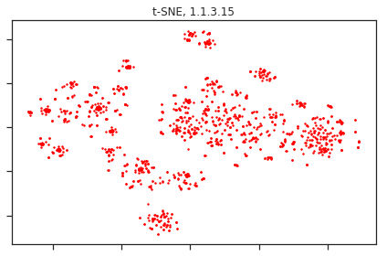

```python
def make_plot(plot_data, name):
    '''
    '''
    plt.scatter(plot_data[:,0], plot_data[:,1], s=2, color='red')
    plt.title(name)
    plt.gca().get_xaxis().set_ticklabels([])
    plt.gca().get_yaxis().set_ticklabels([])
    plt.tight_layout()


X = PCA(n_components=50).fit_transform(moran_data)

# scale the pca to use as initialization
PCAinit = X[:,:2] / np.std(X[:,0]) * 0.0001

# calculate tsne using pca initialization
my_plot = fast_tsne(moran_data, initialization=PCAinit)


display(make_plot(my_plot, 't-SNE, 1.1.3.15'))
```

```python
def highlight_part_of_plot(plot_data, selected_data, background_data):
    '''
    Plot a single ec number
    '''

    plt.scatter(plot_data[:,0][background_data], plot_data[:,1][background_data], s=7, color=[0.8, 0.8, 0.8])
    plt.scatter(plot_data[:,0][selected_data], plot_data[:,1][selected_data], s=7, color='red')
    plt.title('t-SNE')
    plt.gca().get_xaxis().set_ticklabels([])
    plt.gca().get_yaxis().set_ticklabels([])
    plt.tight_layout()


def highlight_by_color(plot_data, colors):
    '''
    Color t-sne plot by categorical values
    '''
    plt.scatter(plot_data[:,0], plot_data[:,1], s=7, color=colors)

    plt.title('t-SNE')
    plt.gca().get_xaxis().set_ticklabels([])
    plt.gca().get_yaxis().set_ticklabels([])
    plt.legend()
    plt.tight_layout()


def get_colors_for_items(item_list):
    '''
    Get a set of unique colors
    '''
    item_set = sorted(list(set(item_list)))

    colors = scales.rainbow(len(item_set))

    return {k:v for k,v in zip(list(item_set), colors)}



def make_ordered_color_list(input_list, input_dict):
    '''
    Make a list of colors that signify some information in the fasta header
    '''
    data = []
    for thing in input_list:

        data.append(str(input_dict[thing]))

    return np.array(data)
```

#### Color t-SNE by clusters to validate that it is good

```
No handles with labels found to put in legend.
```

```
None
```

```
array(['#ff8f2f', '#ff8f2f', '#adff2f', ..., '#ff8f2f', '#ff8f2f',
       '#fff02f'], dtype='<U7')
```

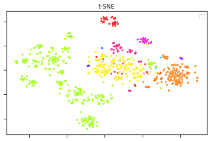

```python
# get a list of all clusters
items_list = moran_subset.cluster.values

# get colors
items_dict = get_colors_for_items(items_list)
color_list = make_ordered_color_list(items_list, items_dict)

# plot it
display(highlight_by_color(my_plot, color_list))


set(items_list)
color_list
```

#### Test different t-SNE settings

```
CPU times: user 2.06 s, sys: 947 ms, total: 3 s
Wall time: 20min 4s
```

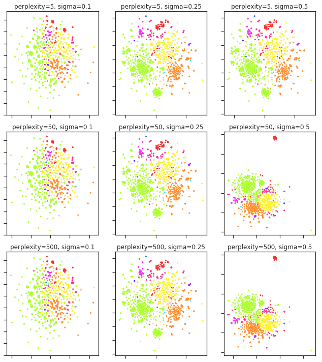

```python
%%time

k = 1000
seed = 42
#iterations = 1000
#noprog = 300
#rate = 200



tsne5_01   = fast_tsne(moran_data, perplexity=5, sigma=0.1,
                       K=k, seed=seed, initialization=PCAinit)
tsne5_025   = fast_tsne(moran_data, perplexity=5, sigma=0.25,
                        K=k, seed=seed, initialization=PCAinit)
tsne5_05   = fast_tsne(moran_data, perplexity=5, sigma=0.5,
                       K=k, seed=seed, initialization=PCAinit)

tsne50_01  = fast_tsne(moran_data, perplexity=50,  sigma=0.1,
                       K=k, seed=seed, initialization=PCAinit)
tsne50_025  = fast_tsne(moran_data, perplexity=50,  sigma=0.25,
                        K=k, seed=seed, initialization=PCAinit)
tsne50_05  = fast_tsne(moran_data, perplexity=50,  sigma=0.5,
                       K=k, seed=seed, initialization=PCAinit)

tsne500_01 = fast_tsne(moran_data, perplexity=500, sigma=0.1,
                       K=k, seed=seed, initialization=PCAinit)
tsne500_025 = fast_tsne(moran_data, perplexity=500, sigma=0.25,
                        K=k, seed=seed, initialization=PCAinit)
tsne500_05 = fast_tsne(moran_data, perplexity=500, sigma=0.5,
                       K=k, seed=seed, initialization=PCAinit)

tsnes  = [tsne5_01, tsne5_025, tsne5_025, tsne50_01, tsne50_025, tsne50_05, tsne500_01, tsne500_025, tsne500_05]
titles = [(5, 0.1), (5, 0.25), (5, 0.5), (50, 0.1), (50, 0.25), (50, 0.5), (500, 0.1), (500, 0.25), (500, 0.5)]

plt.figure(figsize=(9,10))
for i,t in enumerate(tsnes):
    plt.subplot(3,3,i+1)
    plt.scatter(tsnes[i][:,0], tsnes[i][:,1], s=3, color=color_list)
    plt.title('perplexity=%s, sigma=%s' % (titles[i]))
    plt.gca().get_xaxis().set_ticklabels([])
    plt.gca().get_yaxis().set_ticklabels([])
plt.tight_layout()
```

```python
k = 1000
seed = 42
perplexity = 5
sigma = 0.25
rate = 400
```

I like the setting with: k = 1000, perplexity = 5, sigma = 0.25, Let's try to refine that a little more.

```
CPU times: user 804 ms, sys: 478 ms, total: 1.28 s
Wall time: 41min 37s
```

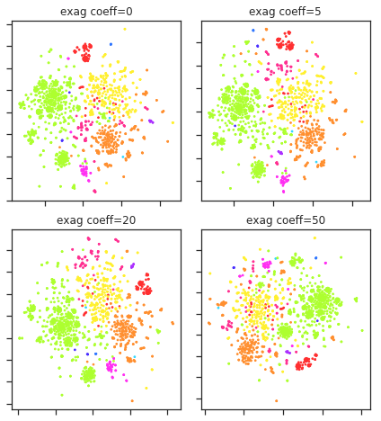

```python
%%time




tsne5_0    = fast_tsne(moran_data, perplexity=perplexity, sigma=sigma,
                       K=k, seed=seed, initialization=PCAinit, learning_rate=rate,
                        early_exag_coeff=0, stop_early_exag_iter=250, max_iter=2000)

tsne5_5    = fast_tsne(moran_data, perplexity=perplexity, sigma=sigma,
                        K=k, seed=seed, initialization=PCAinit, learning_rate=rate,
                      early_exag_coeff=5, stop_early_exag_iter=250, max_iter=2000)

tsne5_20   = fast_tsne(moran_data, perplexity=perplexity, sigma=sigma,
                       K=k, seed=seed, initialization=PCAinit, learning_rate=rate,
                      early_exag_coeff=20, stop_early_exag_iter=250, max_iter=2000)

tsne5_50   = fast_tsne(moran_data, perplexity=perplexity, sigma=sigma,
                       K=k, seed=seed, initialization=PCAinit, learning_rate=rate,
                      early_exag_coeff=50, stop_early_exag_iter=250, max_iter=2000)

tsnes  = [tsne5_0, tsne5_5, tsne5_20, tsne5_50]
titles = [(0), (5), (20), (50)]

plt.figure(figsize=(6,6.6))
for i,t in enumerate(tsnes):
    plt.subplot(2,2,i+1)
    plt.scatter(tsnes[i][:,0], tsnes[i][:,1], s=3, color=color_list)
    plt.title('exag coeff=%s' % (titles[i]))
    plt.gca().get_xaxis().set_ticklabels([])
    plt.gca().get_yaxis().set_ticklabels([])
plt.tight_layout()
```

So the final setting that I use is: k = 1000, perplexity = 5, sigma = 0.25, learning_rate = 400, early_exag_coeff = 20, stop_early_exag_iter = 250, max_iter = 2000.

#### Also test UMAP and MDS

```
[]
```

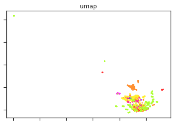

```python
from umap import UMAP

umap = UMAP(n_components=2).fit_transform(moran_data)


plt.scatter(umap[:,0], umap[:,1], s=3, color=color_list)
plt.title('umap')
plt.gca().get_xaxis().set_ticklabels([])
plt.gca().get_yaxis().set_ticklabels([])
```

This umap plot looks terrible, let's not use.

```
[]
```

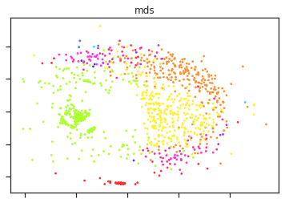

```python
from sklearn.manifold import MDS


mds = MDS(n_components=2, random_state=42).fit_transform(moran_data)

plt.scatter(mds[:,0], mds[:,1], s=3, color=color_list)
plt.title('mds')
plt.gca().get_xaxis().set_ticklabels([])
plt.gca().get_yaxis().set_ticklabels([])
```

This mds plot also looks terrible, let's not use.

#### Compute the "final" plot using parameters that I deem "the best"

```python
my_plot = fast_tsne(moran_data, perplexity=5, sigma=0.25,
                       K=k, seed=42, initialization=PCAinit,
                      early_exag_coeff=20, stop_early_exag_iter=250,
                      learning_rate=400, max_iter=2000)
```